# City Nature Challenge 2022: Graz

Veröffentlichungsdatum

2023-04-24T18:03:47+00:00

## Demo 2022

## Allgemeine Information

Insgesamt wurden 16887 Beobachtungen von 197 Beobachterinnen und Beobachtern hochgeladen. Das ergibt einen Mittelwert von 85.7 Beobachtungen pro Beobachter bzw. Beobachterin und einen Median von 19. Auf Spezies-Ebene wurden 2498 Beobachtungen hochgeladen.

### Top 10 Beobachter/innen

In dieser Liste werden auch doppelte Beobachtungen gezählt, jedoch sollte dies nicht als Tipp betrachtet werden, um an erster Stelle zu stehen.

| Beob. [#] | User |
| --- | --- |
| 1548 | gernotkunz |
| 948 | johannagu |
| 568 | Christian Berg |
| 542 | uwekozina |
| 504 | martina_poeltl |
| 471 | preitler |
| 455 | Peter Bilovitz |
| 442 | Franz Hillebrand |
| 384 | susanneleonhartsberger |
| 376 | tamarita |

### Top 10 Taxa (Spezies-Ebene)

In dieser Liste sind die am häufigsten beobachteten Taxa auf Spezies-Ebene aufgeführt, die bereits identifiziert wurden. Es ist jedoch nicht erforderlich, dass diese von einer zweiten Person bestätigt wurden, um den Forschungsstandard (Research-Grade) zu erreichen.

| Beob. [#] | Wiss. Name | Umgangspr. Name |
| --- | --- | --- |
| 123 | Helix pomatia | Weinbergschnecke |
| 105 | Ajuga reptans | Kriechender Günsel |
| 87 | Alliaria petiolata | Knoblauchsrauke |
| 69 | Hedera helix | Efeu |
| 68 | Urtica dioica | Große Brennessel, Große Brennnessel |
| 63 | Lamium maculatum | Gefleckte Taubnessel |
| 62 | Chelidonium majus | Schöllkraut |
| 62 | Prunus padus | Traubenkirsche, Gewöhnliche Trau... |
| 59 | Cantharis rustica | Soldatenkäfer |
| 58 | Anemonoides nemorosa | Buschwindröschen |

[output cut: 1 more lines]

### Unique Taxa mit Research-Grade

Besonders erfreulich sind natürlich immer einzigartige Funde, die nur von einer Person in der Challenge hochgeladen wurden. In dieser Liste müssen jedoch alle Spezies von einer zweiten Person bestätigt werden, um den Forschungsstandard (Research-Grade) zu erreichen.

| Wiss. Name | Umgangspr. Name | User |
| --- | --- | --- |
| Aethalura punctulata | Grauer Erlen-Rindenspanner | Wolfgang Gessl |
| Conistra erythrocephala | Rotkopf-Wintereule | Wolfgang Gessl |
| Idaea degeneraria | Zweifarbiger Doppellinien-Zwergs... | Wolfgang Gessl |
| Staphylinus dimidiaticornis | Rotflügeliger Moderkäfer | koblmuel |
| Sempervivum globiferum hirtum | NA | gernotkunz |
| Otiorhynchus armadillo | Gürteltier-Dickmaulrüssler | Franz Hillebrand |
| Leucojum aestivum | Sommer-Knotenblume, Spätblühende... | Franz Hillebrand |
| Elaphrus cupreus | Kupferfarbener Uferläufer, Bronz... | rt tzui |
| Agonum emarginatum | NA | rt tzui |
| Acupalpus flavicollis | Nahtstreifen-Buntschnellläufer | rt tzui |

[output cut: 841 more lines]

### Beobachtungs Qualität

iNaturalist unterteilt die Beobachtungsqualität in drei Kategorien. Die Kategorie “causal” umfasst Beobachtungen, bei denen mindestens eines der folgenden Elemente fehlt: das Datum der Beobachtung, der Beobachtungsort oder ein Foto (oder Tonaufnahme). Die Kategorie “needs_id” wird angezeigt, bis mindestens zwei Personen eine Spezies für diesen Upload einstimmig bestimmt haben, ohne Widerspruch. Die letzte und wertvollste Kategorie ist “research”, die bestätigte Beobachtungen auf Spezies-Ebene umfasst.

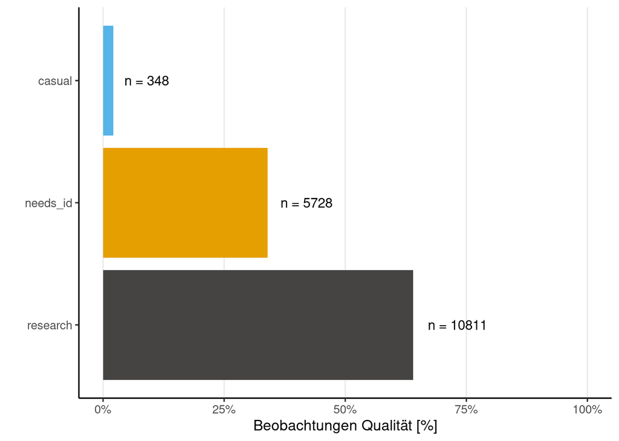

### Beobachtungen Phylum

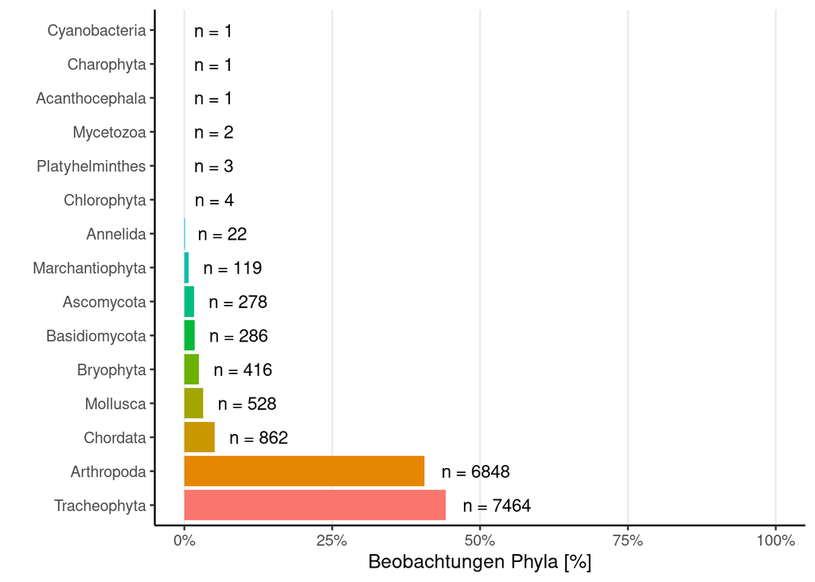

### Insecta - Ordnungen

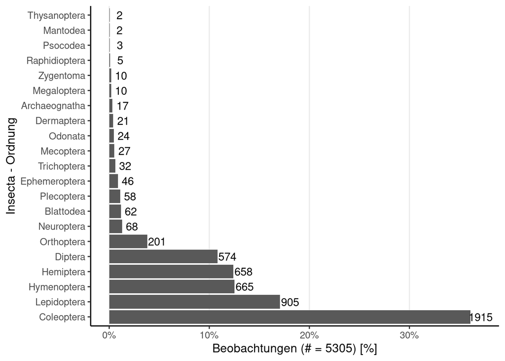

### Beobachtungen mit Konflikt Bestimmungen

| uri | User | Taxa |
| --- | --- | --- |
| https://www.inaturalist.org/observations/113327200 | gernotkunz | Frullania dilatata |
| https://www.inaturalist.org/observations/113327443 | gernotkunz | Brassicaceae |
| https://www.inaturalist.org/observations/113327777 | gernotkunz | Solidago gigantea |
| https://www.inaturalist.org/observations/113358939 | rt tzui | Oligostomis reticulata |
| https://www.inaturalist.org/observations/113363214 | Wolfgang Gessl | Mycelis muralis |
| https://www.inaturalist.org/observations/113373686 | leabraun | Forsythia |
| https://www.inaturalist.org/observations/113411793 | antrum | Porella platyphylla |
| https://www.inaturalist.org/observations/113416031 | antrum | Pyrrhocoris apterus |
| https://www.inaturalist.org/observations/113416880 | Roman Burgsteiner | Metellina |
| https://www.inaturalist.org/observations/113419116 | rt tzui | Callilepis |

[output cut: 192 more lines]

### Rote Liste

Anmerkung: Beinhaltet die Rote Liste aller EU Länder.

| Wiss. Name | Umgangspr. Name | annex_II_priority | annex_II | annex_IV | n |
| --- | --- | --- | --- | --- | --- |
| Bombina variegata | Gelbbauchunke, Bergunke | N | Y | Y | 7 |
| Buxbaumia viridis | Grünes Koboldmoos | N | Y | N | 1 |
| Castor fiber | Europäischer Biber, Eurasischer ... | N | Y | Y | 2 |
| Coronella austriaca | Schlingnatter, Glattnatter, Hase... | N | N | Y | 2 |
| Eriogaster catax | Heckenwollafter | N | Y | Y | 1 |
| Euplagia quadripunctaria | Russischer Bär, Spanische Fahne,... | Y | Y | N | 1 |
| Hucho hucho | Heuch, Huchen | N | Y | N | 1 |
| Hyla arborea | Europäischer Laubfrosch, Heckenf... | N | N | Y | 2 |
| Lacerta agilis | Zauneidechse | N | N | Y | 4 |
| Miniopterus schreibersii | Schreibers Langflügelfledermaus | N | Y | Y | 1 |

[output cut: 8 more lines]

| Wiss. Name | Umgangspr. Name | AnnexI | n |
| --- | --- | --- | --- |
| Ardea alba | Silberreiher | I | 2 |
| Bubo bubo | Uhu, Schuhu, Huhu, Auf, Jutzeule... | I | 2 |
| Certhia brachydactyla | Gartenbaumläufer | I * | 1 |
| Ciconia ciconia | Weißstorch, Klapperstorch | I | 2 |
| Columba palumbus | Ringeltaube, Waldtaube | I * | 19 |
| Dendrocopos major | Buntspecht | I * | 16 |
| Dryocopus martius | Schwarzspecht | I | 2 |
| Ficedula albicollis | Halsbandschnäpper, Halsbandflieg... | I | 5 |
| Fringilla coelebs | Buchfink | I * | 43 |
| Periparus ater | Tannenmeise, Kleine Kohlmeise, K... | I * | 3 |

[output cut: 2 more lines]